# Bayesian GLM Part8

Author

Murray Logan

Published

09/09/2025

# 1 Preparations

Load the necessary libraries

```r
library(tidyverse)
library(brms)
library(dagitty)
library(ggdag)
library(patchwork)
source("helperFunctions.R")
```

# 2 Scenario

To investigate the effects of low light and a herbicide (diuron) on algae, King et al. (2022) set up an experiment in which algae were exposed to different combinations of light levels and diuron concentration. Over a 72 hour period, chlorophyll-a fluorescence and cell density were measured.

The data are in the file **king.csv** in the **data** folder.

**Table** 1: Format of the king.csv data file

| Time | Light | Diuron | Block | t0 | celld | lncelld | PI |
| --- | --- | --- | --- | --- | --- | --- | --- |
| 72 | 20 | 0.11 | 2 | 35.24612 | 125.94344 | 4.835832917 | 1.012390192 |
| 72 | 20 | 0.11 | 3 | 39.6347 | 114.65852 | 4.74195832 | 0.929296694 |
| 72 | 20 | 0.11 | 4 | 34.61918 | 167.32148 | 5.119916992 | 0.977363859 |
| 72 | 20 | 0.33 | 2 | 35.4551 | 126.77936 | 4.842448253 | 1.02771364 |
| 72 | 20 | 0.33 | 3 | 45.69512 | 155.20064 | 5.044718731 | 0.95016989 |
| 72 | 20 | 0.33 | 4 | 46.53104 | 162.72392 | 5.092055022 | 0.972060034 |
| 72 | 20 | 1 | 2 | 48.62084 | 165.85862 | 5.111135739 | 0.914524138 |
| ... | ... | ... | ... | ... | ... | ... | ... |

**Table** 2: Description of the variables in the king data file

| **Time**: | Hour of measurements |
| --- | --- |
| **Light**: | Light level treatment (5, 20, 80μmol photons m-2 s-1) - Predictor variable |
| **Diuron**: | Diuron herbicide concentration (0, 0.11, 0.33, 1, 3μg/L) - Predictor variable |
| **Block**: | Block - we will ignore this for now |
| **t0**: | Cell density at time 0 |
| **celld** | Cell density at treatment level - Response variable |
| **PI** | Photosynthetic inhibition (%), photosynthetic yield (as a % of controls) - Response variable |

# 3 Read in the data

```r
king <- read_csv("../data/king.csv", trim_ws = TRUE)
```

**glimpse**

```r
glimpse(king)
```

```
Rows: 45
Columns: 8
$ Time    <dbl> 72, 72, 72, 72, 72, 72, 72, 72, 72, 72, 72, 72, 72, 72, 72, 72…
$ Light   <dbl> 20, 20, 20, 20, 20, 20, 20, 20, 20, 20, 20, 20, 20, 20, 20, 5,…
$ Diuron  <dbl> 0.11, 0.11, 0.11, 0.33, 0.33, 0.33, 1.00, 1.00, 1.00, 3.00, 3.…
$ Block   <dbl> 2, 3, 4, 2, 3, 4, 2, 3, 4, 2, 3, 4, 2, 3, 4, 2, 3, 4, 2, 3, 4,…
$ t0      <dbl> 35.24612, 39.63470, 34.61918, 35.45510, 45.69512, 46.53104, 48…
$ celld   <dbl> 125.94344, 114.65852, 167.32148, 126.77936, 155.20064, 162.723…
$ lncelld <dbl> 4.835833, 4.741958, 5.119917, 4.842448, 5.044719, 5.092055, 5.…
$ PI      <dbl> 1.0123902, 0.9292967, 0.9773639, 1.0277136, 0.9501699, 0.97206…
```

**head**

```r
## Explore the first 6 rows of the data
head(king)
```

```
# A tibble: 6 × 8
   Time Light Diuron Block    t0 celld lncelld    PI
  <dbl> <dbl>  <dbl> <dbl> <dbl> <dbl>   <dbl> <dbl>
1    72    20   0.11     2  35.2  126.    4.84 1.01
2    72    20   0.11     3  39.6  115.    4.74 0.929
3    72    20   0.11     4  34.6  167.    5.12 0.977
4    72    20   0.33     2  35.5  127.    4.84 1.03
5    72    20   0.33     3  45.7  155.    5.04 0.950
6    72    20   0.33     4  46.5  163.    5.09 0.972
```

**str**

```r
str(king)
```

```
spc_tbl_ [45 × 8] (S3: spec_tbl_df/tbl_df/tbl/data.frame)
 $ Time   : num [1:45] 72 72 72 72 72 72 72 72 72 72 ...
 $ Light  : num [1:45] 20 20 20 20 20 20 20 20 20 20 ...
 $ Diuron : num [1:45] 0.11 0.11 0.11 0.33 0.33 0.33 1 1 1 3 ...
 $ Block  : num [1:45] 2 3 4 2 3 4 2 3 4 2 ...
 $ t0     : num [1:45] 35.2 39.6 34.6 35.5 45.7 ...
 $ celld  : num [1:45] 126 115 167 127 155 ...
 $ lncelld: num [1:45] 4.84 4.74 5.12 4.84 5.04 ...
 $ PI     : num [1:45] 1.012 0.929 0.977 1.028 0.95 ...
 - attr(*, "spec")=
  .. cols(
  ..   Time = col_double(),
  ..   Light = col_double(),
  ..   Diuron = col_double(),
  ..   Block = col_double(),
  ..   t0 = col_double(),
  ..   celld = col_double(),
  ..   lncelld = col_double(),
  ..   PI = col_double()
  .. )
 - attr(*, "problems")=<externalptr>
```

**Easystats (datawizard)**

```r
king |> datawizard::data_codebook()
```

```
king (45 rows and 8 variables, 8 shown)

ID | Name    | Type    | Missings |          Values |           N
---+---------+---------+----------+-----------------+------------
1  | Time    | numeric | 0 (0.0%) |              72 | 45 (100.0%)
---+---------+---------+----------+-----------------+------------
2  | Light   | numeric | 0 (0.0%) |               5 | 15 ( 33.3%)
   |         |         |          |              20 | 15 ( 33.3%)
   |         |         |          |              80 | 15 ( 33.3%)
---+---------+---------+----------+-----------------+------------
3  | Diuron  | numeric | 0 (0.0%) |               0 |  9 ( 20.0%)
   |         |         |          |            0.11 |  9 ( 20.0%)
   |         |         |          |            0.33 |  9 ( 20.0%)
   |         |         |          |               1 |  9 ( 20.0%)
   |         |         |          |               3 |  9 ( 20.0%)
---+---------+---------+----------+-----------------+------------
4  | Block   | numeric | 0 (0.0%) |               2 | 15 ( 33.3%)
   |         |         |          |               3 | 15 ( 33.3%)
   |         |         |          |               4 | 15 ( 33.3%)
---+---------+---------+----------+-----------------+------------
5  | t0      | numeric | 0 (0.0%) |  [29.19, 68.89] |          45
---+---------+---------+----------+-----------------+------------
6  | celld   | numeric | 0 (0.0%) | [37.96, 270.56] |          45
---+---------+---------+----------+-----------------+------------
7  | lncelld | numeric | 0 (0.0%) |     [3.64, 5.6] |          45
---+---------+---------+----------+-----------------+------------
8  | PI      | numeric | 0 (0.0%) |    [0.63, 1.53] |          45
-----------------------------------------------------------------
```

# 4 Process data

```r
king <- king |>
  mutate(
    fLight = factor(Light),
    fDiuron = factor(Diuron),
    Block = factor(Block)
  )
```

# 5 Research questions

- Q1: estimate the effect of light on photosynthetic inhibition
- Q2: estimate the effect of photosynthetic inhibition on algal cell density
- Q3: estimate the effect of light on algal cell density
- Q4: estimate the effect of diuron (herbicide) on photosynthetic inhibition
- Q5: estimate the effect of diuron (herbicide) on algal cell density

# 6 Naive approach

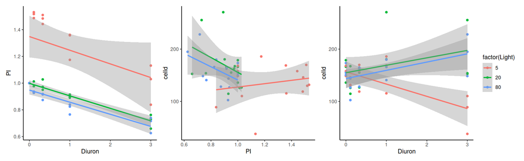

```r
g1 <-
  king |>
  ggplot(aes(y = PI, x = Diuron, colour = factor(Light))) +
  geom_point() +
  geom_smooth(method = "lm") +
  theme_classic()
g2 <-
  king |>
  ggplot(aes(y = celld, x = PI, colour = factor(Light))) +
  geom_point() +
  geom_smooth(method = "lm") +
  theme_classic()
g3 <-
  king |>
  ggplot(aes(y = celld, x = Diuron, colour = factor(Light))) +
  geom_point() +
  geom_smooth(method = "lm") +
  theme_classic()
g1 + g2 + g3 + plot_layout(guides = "collect")
```

**Response: PI**

```r
form <- bf(PI ~ scale(Diuron) * factor(Light))
## summarise data to help inform priors
king |>
  group_by(Light) |>
  summarise(PI_mu = median(PI), PI_sd = sd(PI), PI_mad = mad(PI))
```

```
# A tibble: 3 × 4
  Light PI_mu PI_sd PI_mad
  <dbl> <dbl> <dbl>  <dbl>
1     5 1.36  0.241 0.256
2    20 0.950 0.112 0.0739
3    80 0.915 0.114 0.125
```

```r
## define priors
priors <- prior(normal(1.4, 0.3), class = "Intercept") +
  prior(normal(0, 0.5), class = "b") +
  prior(student_t(3, 0, 0.3), class = "sigma")
## fit the mode
king_brms0a <- brm(
  form,
  prior = priors,
  data = king,
  refresh = 0,
  backend = "rstan"
)
```

```r
summary(king_brms0a)
```

```
 Family: gaussian
  Links: mu = identity; sigma = identity
Formula: PI ~ scale(Diuron) * factor(Light)
   Data: king (Number of observations: 45)
  Draws: 4 chains, each with iter = 2000; warmup = 1000; thin = 1;
         total post-warmup draws = 4000

Regression Coefficients:
                          Estimate Est.Error l-95% CI u-95% CI Rhat Bulk_ESS
Intercept                     1.26      0.03     1.19     1.32 1.00     2946
scaleDiuron                  -0.11      0.04    -0.18    -0.05 1.00     2117
factorLight20                -0.34      0.05    -0.44    -0.24 1.00     3231
factorLight80                -0.39      0.05    -0.48    -0.29 1.00     3198
scaleDiuron:factorLight20     0.01      0.05    -0.09     0.11 1.00     2211
scaleDiuron:factorLight80     0.01      0.05    -0.09     0.11 1.00     2390
                          Tail_ESS
Intercept                     2599
scaleDiuron                   2340
factorLight20                 3042
factorLight80                 2715
scaleDiuron:factorLight20     2687
scaleDiuron:factorLight80     2367

Further Distributional Parameters:
      Estimate Est.Error l-95% CI u-95% CI Rhat Bulk_ESS Tail_ESS
sigma     0.13      0.02     0.11     0.17 1.00     3162     3160

Draws were sampled using sampling(NUTS). For each parameter, Bulk_ESS
and Tail_ESS are effective sample size measures, and Rhat is the potential
scale reduction factor on split chains (at convergence, Rhat = 1).
```

**Conclusions:**

- increasing diuron concentration associated with decreasing photosynthetic inhibition ()
- increasing light is associated with decreasing photosynthetic inhibition

**Response: cell density**

```r
form <- bf(celld ~ scale(Diuron) + scale(PI) + Light)
## summarise data to help inform priors
king |>
  group_by(Light) |>
  summarise(celld_mu = median(celld), celld_sd = sd(celld), celld_mad = mad(celld))
```

```
# A tibble: 3 × 4
  Light celld_mu celld_sd celld_mad
  <dbl>    <dbl>    <dbl>     <dbl>
1     5     146.     38.0      33.8
2    20     163.     43.4      23.9
3    80     155.     30.1      20.8
```

```r
## define priors
priors <- prior(normal(150, 50), class = "Intercept") +
  prior(normal(0, 20), class = "b") +
  prior(student_t(3, 0, 50), class = "sigma")
## fit the mode
king_brms0b <- brm(
  form,
  prior = priors,
  data = king |> mutate(Light = factor(Light)),
  refresh = 0,
  backend = "rstan"
)
```

```r
summary(king_brms0b)
```

```
 Family: gaussian
  Links: mu = identity; sigma = identity
Formula: celld ~ scale(Diuron) + scale(PI) + Light
   Data: mutate(king, Light = factor(Light)) (Number of observations: 45)
  Draws: 4 chains, each with iter = 2000; warmup = 1000; thin = 1;
         total post-warmup draws = 4000

Regression Coefficients:
            Estimate Est.Error l-95% CI u-95% CI Rhat Bulk_ESS Tail_ESS
Intercept     148.05      9.65   129.02   166.89 1.00     2798     2451
scaleDiuron    -1.34      6.57   -14.31    11.55 1.00     3116     2770
scalePI        -8.23      7.70   -23.70     6.52 1.00     2791     2748
Light20        12.93     13.26   -13.33    38.84 1.00     3161     3017
Light80         3.76     13.59   -22.81    29.61 1.00     2837     2809

Further Distributional Parameters:
      Estimate Est.Error l-95% CI u-95% CI Rhat Bulk_ESS Tail_ESS
sigma    38.89      4.42    31.56    48.48 1.00     3922     2861

Draws were sampled using sampling(NUTS). For each parameter, Bulk_ESS
and Tail_ESS are effective sample size measures, and Rhat is the potential
scale reduction factor on split chains (at convergence, Rhat = 1).
```

**Conclusions:**

- no effect of diuron concentration on algal cell density
- no effect of photosynthetic inhibition on algal cell density
- no effect of light on algal cell density

# 7 Structural Causal Modelling

1. Create a conceptual model of the system of interest
2. Choose a statistical test
3. Test the consistency of your conceptual model with the data
4. Identify biases (confounding, overcontrol, collider) that you need to adjust for when testing the cause of interest
5. Test for causality with the appropriate statistical test
6. Repeat steps 3-5 for each cause of interest
7. Repeat steps 1-6 for other conceptual models

# 8 Step 1 - conceptual model

King et al. (2022) hypothesised that photosynthetic inhibition would be effected by light levels and that the diuron herbicide would effect photosynthesis by blocking certain chemical reactions. In tern, changes in photosynthesis could have an effect on algal cell density. Furthermore, diuron might also have a direct effect on cell density by causing cell damage.

Lets start by creating a DAG that reflects this conceptual model.

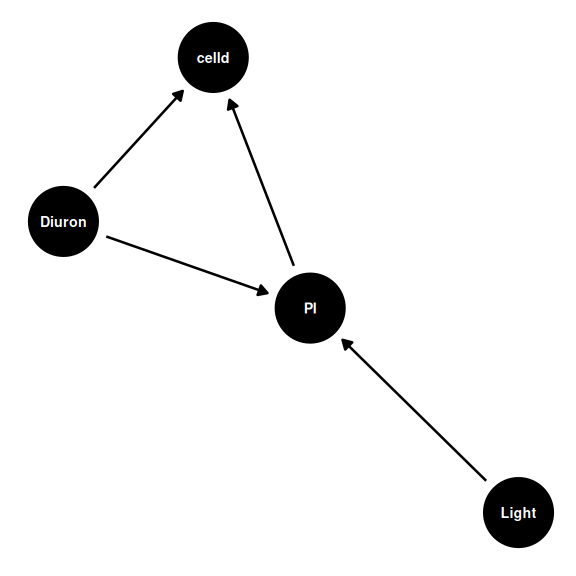

```r
king_dag <- dagify(
  celld ~ PI + Diuron,
  PI ~ Light + Diuron,
  exposure = "Light",
  outcome = "celld"
)
ggdag(king_dag, text = TRUE, text_size = 2.5) +
  theme_dag_blank()
```

# 9 Step 2 - choose a statistical test

For the main inference tests we will fit Bayesian generalized linear models, however, for the purpose of testing the consistency of our conceptual model (DAG) with data, we will just use more simple frequentist analyses.

# 10 Step 3 - test the consistency of the DAG with observed data

Lets now determine what all the implied assumptions (conditional independencies) of our DAG are.

```r
dagitty::impliedConditionalIndependencies(king_dag)
```

```
Dirn _||_ Lght
Lght _||_ clld | Dirn, PI
```

**Conclusions**:

- Diuron is independent of Light
- Light is independent of celld when conditioned on both Diuron and PI

And challenge those assumptions with the data.

```r
tests <- localTests(x = king_dag, data = king)
tests
```

```
                             estimate  p.value       2.5%     97.5%
Dirn _||_ Lght             0.00000000 1.000000 -0.2936838 0.2936838
Lght _||_ clld | Dirn, PI -0.04685251 0.766819 -0.3427060 0.2571860
```

**Conclusions**:

- it seems that our conceptual model is consistent with the data.

# 11 Step 4 - identify biases that need to be adjusted for

Our goal is to be able to investigate the effects of light and diuron on both algal photosynthesis and cell density. So lets explore each one separately, starting with photosynthesis.

**Total effect of Light on photosynthesis**

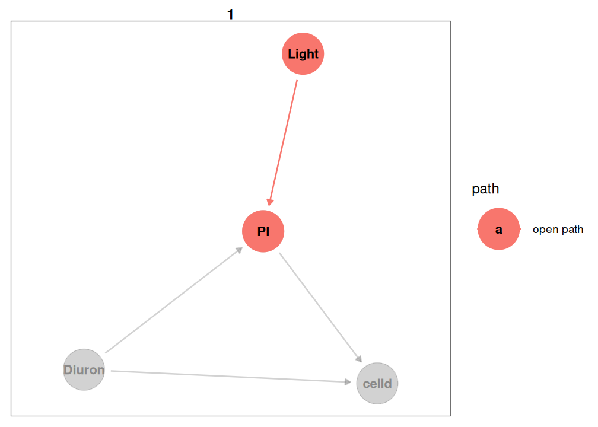

```r
ggdag_paths(king_dag, from = "Light", to = "PI", text_col = "black", shadow = TRUE) +
  theme_dag_blank(panel.border = element_rect(fill = NA))
```

**Conclusions**:

- there is a single direct path

```r
adjustmentSets(king_dag,
  exposure = "Light",
  outcome = "PI",
  type = "minimal",
  effect = "total"
)
```

```
 {}
```

We can also ask whether there are any other optional covariates that we could include without introducing biases.

```r
adjustmentSets(king_dag,
  exposure = "Light",
  outcome = "PI",
  type = "canonical",
  effect = "total"
)
```

```
{ Diuron }
```

- we could also include diuron

```r
adjustmentSets(king_dag,
  exposure = "Light",
  outcome = "PI",
  type = "minimal",
  effect = "direct"
)
```

```
 {}
```

**Total Light on cell density**

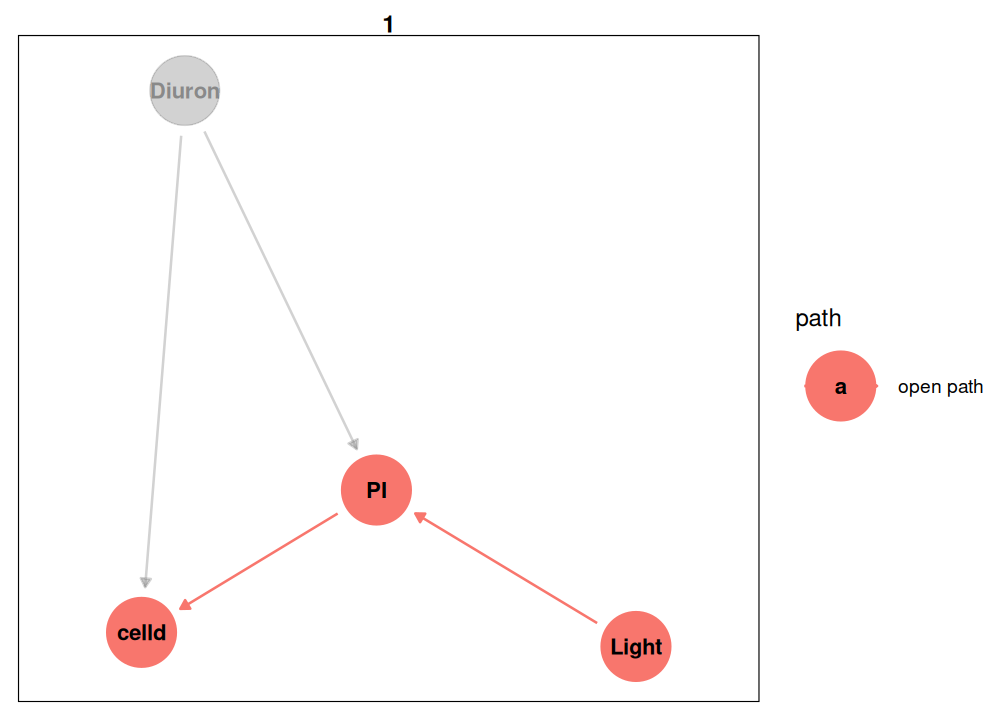

```r
ggdag_paths(king_dag, from = "Light", to = "celld", text_col = "black", shadow = TRUE) +
  theme_dag_blank(panel.border = element_rect(fill = NA))
```

**Conclusions**:

- there is a single path
  - a pipe (`Light -> PI -> celld`)

```r
adjustmentSets(king_dag,
  exposure = "Light",
  outcome = "celld",
  type = "minimal",
  effect = "total"
)
```

```
 {}
```

- to explore the total effects of Light on celld, we do not condition on anything

We can also ask whether there are any other optional covariates that we could include without introducing biases.

```r
adjustmentSets(king_dag,
  exposure = "Light",
  outcome = "celld",
  type = "canonical",
  effect = "total"
)
```

```
{ Diuron }
```

- we could also include diuron

The conceptual model does not include a direct pathway from Light to cell density, but if we wanted to examine this, what would we need to condition on?

```r
adjustmentSets(king_dag,
  exposure = "Light",
  outcome = "celld",
  type = "minimal",
  effect = "direct"
)
```

```
{ Diuron, PI }
```

- we would need to include both Diuron and PI

**Total photosynthesis on cell density**

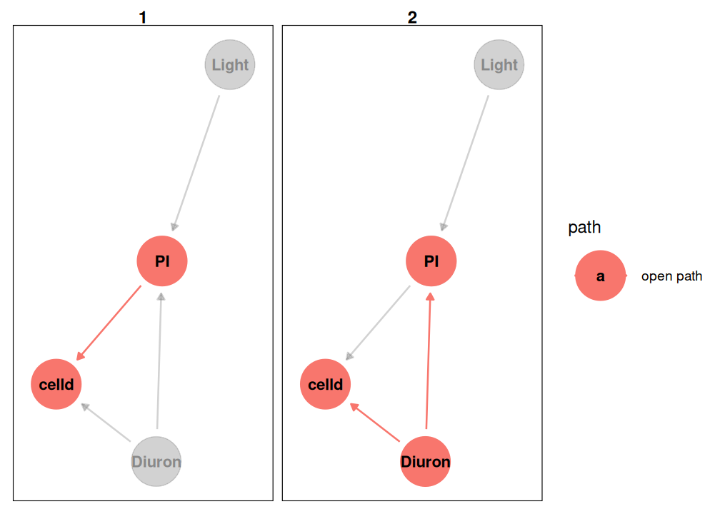

```r
ggdag_paths(king_dag, from = "PI", to = "celld", text_col = "black", shadow = TRUE) +
  theme_dag_blank(panel.border = element_rect(fill = NA))
```

**Conclusions**:

- there is are two paths
  - direct (`PI -> celld`)
  - a forl (`PI <- Diuron -> celld`)
    - this is a backdoor
    - we want to block this path

```r
adjustmentSets(king_dag,
  exposure = "PI",
  outcome = "celld",
  type = "minimal",
  effect = "total"
)
```

```
{ Diuron }
```

- to explore the total effects of photosynthesis inhibition on cell density, we **must** condition on diuron

We can also ask whether there are any other optional covariates that we could include without introducing biases.

```r
adjustmentSets(king_dag,
  exposure = "PI",
  outcome = "celld",
  type = "canonical",
  effect = "total"
)
```

```
{ Diuron, Light }
```

- we could also include light, but we already know that we must include diuron

The conceptual model also includes a direct pathway from PI to cell density, so if we wanted to examine this, what would we need to condition on?

```r
adjustmentSets(king_dag,
  exposure = "PI",
  outcome = "celld",
  type = "minimal",
  effect = "direct"
)
```

```
{ Diuron }
```

- again, as a minimum, we **must** condition on diuron

**Diuron on cell density**

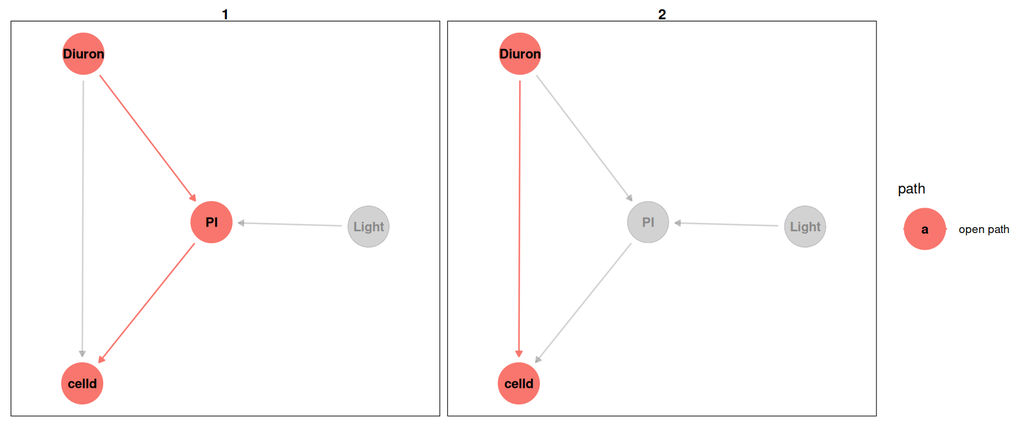

```r
ggdag_paths(king_dag, from = "Diuron", to = "celld", text_col = "black", shadow = TRUE) +
  theme_dag_blank(panel.border = element_rect(fill = NA))
```

**Conclusions**:

- there are two paths
  - one is a pipe (`Diron -> PI -> celld`)
  - one is direct (`Diuron -> celld`)

```r
adjustmentSets(king_dag,
  exposure = "Diuron",
  outcome = "celld",
  type = "minimal",
  effect = "total"
)
```

```
 {}
```

- to explore the total effects of Diuron on cell density, we do not condition on any other covariate

We can also ask whether there are any other optional covariates that we could include without introducing biases.

```r
adjustmentSets(king_dag,
  exposure = "Diuron",
  outcome = "celld",
  type = "canonical",
  effect = "total"
)
```

```
{ Light }
```

- we could also include Light

If we wanted to examine the direct effects of Diuron on cell density, what would we need to condition on?

```r
adjustmentSets(king_dag,
  exposure = "Diuron",
  outcome = "celld",
  type = "minimal",
  effect = "direct"
)
```

```
{ PI }
```

- we would need to include PI

**Diuron on photosynthetic inhibition**

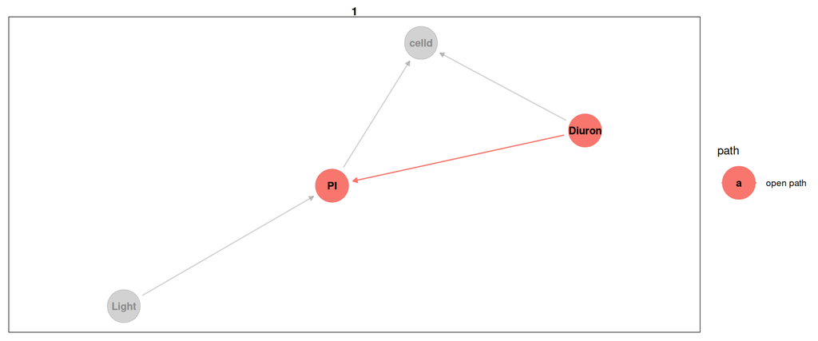

```r
ggdag_paths(king_dag, from = "Diuron", to = "PI", text_col = "black", shadow = TRUE) +
  theme_dag_blank(panel.border = element_rect(fill = NA))
```

**Conclusions**:

```r
adjustmentSets(king_dag,
  exposure = "Diuron",
  outcome = "PI",
  type = "minimal",
  effect = "total"
)
```

```
 {}
```

- to explore the total effects of Diuron on cell density, we do not condition on any other covariate

We can also ask whether there are any other optional covariates that we could include without introducing biases.

```r
adjustmentSets(king_dag,
  exposure = "Diuron",
  outcome = "PI",
  type = "canonical",
  effect = "total"
)
```

```
{ Light }
```

- we could also include Light

If we wanted to examine the direct effects of Diuron on cell density, what would we need to condition on?

```r
adjustmentSets(king_dag,
  exposure = "Diuron",
  outcome = "PI",
  type = "minimal",
  effect = "direct"
)
```

```
 {}
```

**Conclusions**:

- Response: PI
  - Light
    - can include diuron
  - Diuron
    - can also have light
- Response: celld
  - Light
    - total: can include diuron
    - direct: must include PI and diuron
  - PI
    - total: must include diuron
    - total: can also include Light
    - direct: must include diuron
  - Diuron
    - total: can include Light
    - direct: must include PI

PI: ~ Light + Diuron Celld (total): ~ Light + Diuron

# 12 Step 5 - test for causality

**Total effect of Light on photosynthesis**

```r
king <- king |>
  mutate(
    fLight = factor(Light),
    fDiuron = factor(Diuron),
    Block = factor(Block)
  )
```

### 12.0.1 Exploratory data analysis

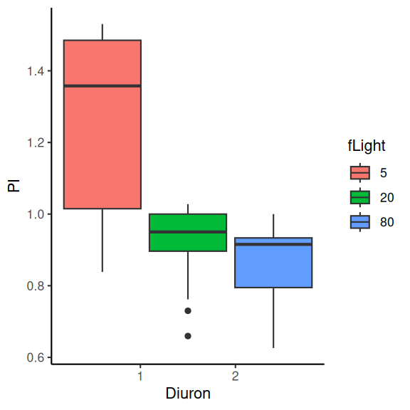

```r
king |>
  ggplot(aes(y = PI, x = Diuron, fill = fLight)) +
  geom_boxplot() +
  theme_classic()
```

```r
form <- bf(PI ~ fLight * scale(Diuron))
## summarise data to help inform priors
king |>
  group_by(fLight) |>
  summarise(PI_mu = median(PI), PI_sd = sd(PI), PI_mad = mad(PI))
```

```
# A tibble: 3 × 4
  fLight PI_mu PI_sd PI_mad
  <fct>  <dbl> <dbl>  <dbl>
1 5      1.36  0.241 0.256
2 20     0.950 0.112 0.0739
3 80     0.915 0.114 0.125
```

```r
## define priors
priors <- prior(normal(1.4, 0.3), class = "Intercept") +
  prior(normal(0, 0.5), class = "b") +
  prior(student_t(3, 0, 0.3), class = "sigma")
## fit the mode
king_brms1a <- brm(
  form,
  prior = priors,
  data = king,
  refresh = 0,
  backend = "rstan"
)
```

```r
summary(king_brms1a)
```

```
 Family: gaussian
  Links: mu = identity; sigma = identity
Formula: PI ~ fLight * scale(Diuron)
   Data: king (Number of observations: 45)
  Draws: 4 chains, each with iter = 2000; warmup = 1000; thin = 1;
         total post-warmup draws = 4000

Regression Coefficients:
                     Estimate Est.Error l-95% CI u-95% CI Rhat Bulk_ESS
Intercept                1.26      0.03     1.18     1.32 1.00     3291
fLight20                -0.34      0.05    -0.43    -0.24 1.00     3413
fLight80                -0.38      0.05    -0.48    -0.28 1.00     3758
scaleDiuron             -0.11      0.04    -0.18    -0.04 1.00     2458
fLight20:scaleDiuron     0.01      0.05    -0.09     0.11 1.00     2846
fLight80:scaleDiuron     0.01      0.05    -0.09     0.11 1.00     2652
                     Tail_ESS
Intercept                2804
fLight20                 2576
fLight80                 3132
scaleDiuron              2670
fLight20:scaleDiuron     2987
fLight80:scaleDiuron     3093

Further Distributional Parameters:
      Estimate Est.Error l-95% CI u-95% CI Rhat Bulk_ESS Tail_ESS
sigma     0.13      0.02     0.11     0.17 1.00     3574     2791

Draws were sampled using sampling(NUTS). For each parameter, Bulk_ESS
and Tail_ESS are effective sample size measures, and Rhat is the potential
scale reduction factor on split chains (at convergence, Rhat = 1).
```

**Conclusions:**

- increasing light reduces photosynthetic inhibition
- increasing diuron reduces photosynthetic inhibition

**Total effect of Light on cell density**

### 12.0.2 Exploratory data analysis

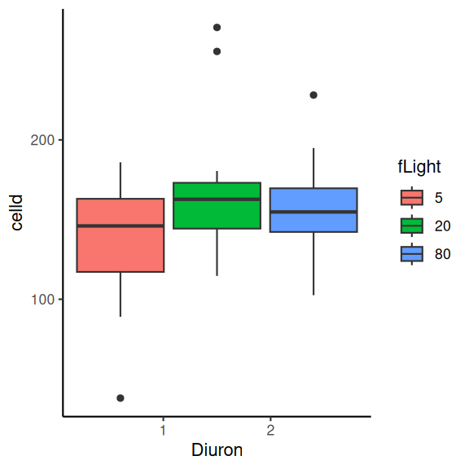

```r
king |>
  ggplot(aes(y = celld, x = Diuron, fill = fLight)) +
  geom_boxplot() +
  theme_classic()
```

```r
form <- bf(celld ~ fLight * scale(Diuron))
## summarise data to help inform priors
king |>
  group_by(fLight) |>
  summarise(celld_mu = median(celld), celld_sd = sd(celld), celld_mad = mad(celld))
```

```
# A tibble: 3 × 4
  fLight celld_mu celld_sd celld_mad
  <fct>     <dbl>    <dbl>     <dbl>
1 5          146.     38.0      33.8
2 20         163.     43.4      23.9
3 80         155.     30.1      20.8
```

```r
## define priors
priors <- prior(normal(150, 50), class = "Intercept") +
  prior(normal(0, 30), class = "b") +
  prior(student_t(3, 0, 50), class = "sigma")
## fit the mode
king_brms2a <- brm(
  form,
  prior = priors,
  data = king,
  refresh = 0,
  backend = "rstan"
)
```

```r
summary(king_brms2a)
```

```
 Family: gaussian
  Links: mu = identity; sigma = identity
Formula: celld ~ fLight * scale(Diuron)
   Data: king (Number of observations: 45)
  Draws: 4 chains, each with iter = 2000; warmup = 1000; thin = 1;
         total post-warmup draws = 4000

Regression Coefficients:
                     Estimate Est.Error l-95% CI u-95% CI Rhat Bulk_ESS
Intercept              139.18      7.82   124.41   154.62 1.00     3658
fLight20                26.06     11.04     3.96    47.55 1.00     3892
fLight80                17.08     10.85    -4.63    37.80 1.00     4003
scaleDiuron            -19.02      7.80   -33.91    -3.77 1.00     2221
fLight20:scaleDiuron    32.30     11.07    10.05    53.06 1.00     2551
fLight80:scaleDiuron    33.94     10.97    11.58    55.41 1.00     2587
                     Tail_ESS
Intercept                3047
fLight20                 2938
fLight80                 3266
scaleDiuron              2654
fLight20:scaleDiuron     2935
fLight80:scaleDiuron     2600

Further Distributional Parameters:
      Estimate Est.Error l-95% CI u-95% CI Rhat Bulk_ESS Tail_ESS
sigma    33.39      3.89    26.67    41.73 1.00     3645     2917

Draws were sampled using sampling(NUTS). For each parameter, Bulk_ESS
and Tail_ESS are effective sample size measures, and Rhat is the potential
scale reduction factor on split chains (at convergence, Rhat = 1).
```

**Conclusions:**

- increasing light increases algal cell density (although only at 20 units)
- increasing diuron concentration reduces algal cell density
- however, there is an interaction between diuron and light levels

**Total effect of photosynthetic inhibition on cell density**

### 12.0.3 Exploratory data analysis

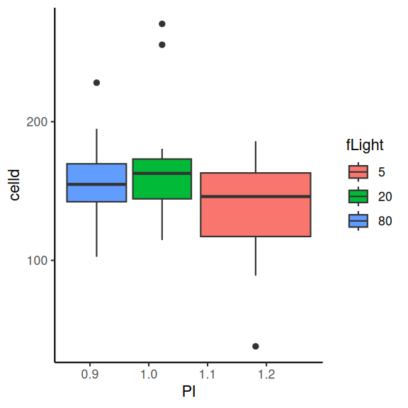

```r
king |>
  ggplot(aes(y = celld, x = PI, fill = fLight)) +
  geom_boxplot() +
  theme_classic()
```

```r
form <- bf(celld ~ scale(PI) * fLight * scale(Diuron))
## summarise data to help inform priors
king |>
  group_by(fLight) |>
  summarise(celld_mu = median(celld), celld_sd = sd(celld), celld_mad = mad(celld))
```

```
# A tibble: 3 × 4
  fLight celld_mu celld_sd celld_mad
  <fct>     <dbl>    <dbl>     <dbl>
1 5          146.     38.0      33.8
2 20         163.     43.4      23.9
3 80         155.     30.1      20.8
```

```r
## define priors
priors <- prior(normal(150, 50), class = "Intercept") +
  prior(normal(0, 30), class = "b") +
  prior(student_t(3, 0, 50), class = "sigma")
## fit the mode
king_brms3a <- brm(
  form,
  prior = priors,
  data = king,
  refresh = 0,
  backend = "rstan"
)
```

```r
summary(king_brms3a)
```

```
 Family: gaussian
  Links: mu = identity; sigma = identity
Formula: celld ~ scale(PI) * fLight * scale(Diuron)
   Data: king (Number of observations: 45)
  Draws: 4 chains, each with iter = 2000; warmup = 1000; thin = 1;
         total post-warmup draws = 4000

Regression Coefficients:
                             Estimate Est.Error l-95% CI u-95% CI Rhat Bulk_ESS
Intercept                      143.48     10.75   122.50   165.35 1.00     4029
scalePI                         -6.71      8.84   -24.40    10.48 1.00     3343
fLight20                        16.14     16.74   -17.59    49.26 1.00     3137
fLight80                         2.87     18.23   -32.74    39.26 1.00     2977
scaleDiuron                    -22.76      8.97   -39.76    -4.43 1.00     4077
scalePI:fLight20               -18.44     25.39   -67.52    31.47 1.00     4272
scalePI:fLight80                 0.22     22.32   -45.19    44.48 1.00     3956
scalePI:scaleDiuron             -1.01     10.97   -23.25    20.66 1.00     3692
fLight20:scaleDiuron            33.06     19.61    -5.98    71.11 1.00     3311
fLight80:scaleDiuron            18.48     20.20   -21.10    57.90 1.00     3269
scalePI:fLight20:scaleDiuron    10.00     19.37   -28.09    47.66 1.00     3600
scalePI:fLight80:scaleDiuron   -16.35     18.56   -51.42    20.67 1.00     3535
                             Tail_ESS
Intercept                        3018
scalePI                          2946
fLight20                         2289
fLight80                         2409
scaleDiuron                      3029
scalePI:fLight20                 3012
scalePI:fLight80                 2757
scalePI:scaleDiuron              2723
fLight20:scaleDiuron             2958
fLight80:scaleDiuron             2739
scalePI:fLight20:scaleDiuron     2854
scalePI:fLight80:scaleDiuron     3145

Further Distributional Parameters:
      Estimate Est.Error l-95% CI u-95% CI Rhat Bulk_ESS Tail_ESS
sigma    33.76      4.11    26.81    42.84 1.00     3647     3169

Draws were sampled using sampling(NUTS). For each parameter, Bulk_ESS
and Tail_ESS are effective sample size measures, and Rhat is the potential
scale reduction factor on split chains (at convergence, Rhat = 1).
```

**Conclusions:**

- no evidence that photosynthetic inhibition has an effect on algal cell density
- but ignore diuron and light

**Total effect of diuron on cell density**

### 12.0.4 Exploratory data analysis

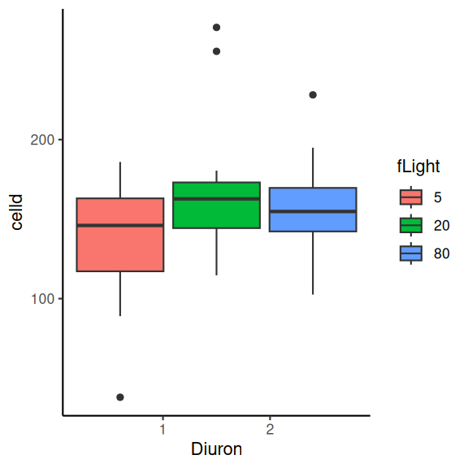

```r
king |>
  ggplot(aes(y = celld, x = Diuron, fill = fLight)) +
  geom_boxplot() +
  theme_classic()
```

```r
form <- bf(celld ~ fLight * scale(Diuron))
## summarise data to help inform priors
king |>
  group_by(fLight) |>
  summarise(celld_mu = median(celld), celld_sd = sd(celld), celld_mad = mad(celld))
```

```
# A tibble: 3 × 4
  fLight celld_mu celld_sd celld_mad
  <fct>     <dbl>    <dbl>     <dbl>
1 5          146.     38.0      33.8
2 20         163.     43.4      23.9
3 80         155.     30.1      20.8
```

```r
## define priors
priors <- prior(normal(150, 50), class = "Intercept") +
  prior(normal(0, 30), class = "b") +
  prior(student_t(3, 0, 50), class = "sigma")
## fit the mode
king_brms4a <- brm(
  form,
  prior = priors,
  data = king,
  refresh = 0,
  backend = "rstan"
)
```

```r
summary(king_brms4a)
```

```
 Family: gaussian
  Links: mu = identity; sigma = identity
Formula: celld ~ fLight * scale(Diuron)
   Data: king (Number of observations: 45)
  Draws: 4 chains, each with iter = 2000; warmup = 1000; thin = 1;
         total post-warmup draws = 4000

Regression Coefficients:
                     Estimate Est.Error l-95% CI u-95% CI Rhat Bulk_ESS
Intercept              139.23      8.16   123.67   155.23 1.00     3742
fLight20                26.08     11.35     3.29    48.46 1.00     3797
fLight80                17.05     11.18    -4.85    38.58 1.00     3406
scaleDiuron            -18.89      8.12   -34.43    -2.58 1.00     2358
fLight20:scaleDiuron    31.95     11.49     8.91    53.64 1.00     2597
fLight80:scaleDiuron    33.69     11.20    11.07    55.12 1.00     2975
                     Tail_ESS
Intercept                2949
fLight20                 3137
fLight80                 3113
scaleDiuron              2315
fLight20:scaleDiuron     2489
fLight80:scaleDiuron     2899

Further Distributional Parameters:
      Estimate Est.Error l-95% CI u-95% CI Rhat Bulk_ESS Tail_ESS
sigma    33.44      4.03    26.60    42.62 1.00     3517     2702

Draws were sampled using sampling(NUTS). For each parameter, Bulk_ESS
and Tail_ESS are effective sample size measures, and Rhat is the potential
scale reduction factor on split chains (at convergence, Rhat = 1).
```

**Conclusions:**

- increasing light levels increase algal cell density
- increasing diuron concentration decreases algal cell density
- there is evidence of an interaction between light and diuron concentration

## References

King, Oliver C., Jason P. van de Merwe, Christopher J. Brown, Michael St J. Warne, and A. Smith Rachael. 2022. “Individual and Combined Effects of Diuron and Light Reduction on Marine Microalgae.” *Ecotoxicology and Environmental Safety*. https://doi.org/https://doi.org/10.1016/j.ecoenv.2022.113729.